# Statistical Inference: Central Limit Theorem

Vasilena Taralova

January 29, 2017

# 1 Introduction

The goal of this project is to investigate the exponential distribution in the context of the Central Limit Theorem (CLT). We apply the CLT to compare the exponential distribution to the large sample distribution of sample means of a collection of $n$ independent and identically distributed (iid) exponential observations. The CLT states that for sufficiently large $n$, the exponential sample mean follows a normal distribution with mean equal to the exponential population mean and variance equal to the population variance divided by $n$. In this project we demonstrate numerically that the CLT holds.

We will need the following packages:

```r
library(ggplot2)
library(gridExtra)
```

# 2 The exponential distribution

The probability density function of the exponential distribution is given by:

$$f(x;\lambda) = \left\{
\begin{array}{l}
\lambda e^{-\lambda x}, \quad x\geq 0, \\
0, \quad x<0,
\end{array}
\right.$$
where $\lambda$ is the rate parameter. The cumulative distribution function is:

$$F(x;\lambda) = \left\{
\begin{array}{l}
1 - e^{-\lambda x}, \quad x\geq 0, \\
0, \quad x<0,
\end{array}
\right.$$
The expected value of an exponential random variable $X$ is $E(X)=\dfrac{1}{\lambda}$ and the variance is $Var(X)=\dfrac{1}{\lambda^2}$.

We simulate the exponential distribution in R with the function call “rexp(n, lambda)” where “lambda” is the rate parameter. We set $\lambda=0.2$ for all of the simulations. We investigate the distribution of sample means of 40 exponentials in a thousand simulations. This means that we generate 40 random exponential observations, find their sample mean, store the average and then repeat this process 1000 times. As a result we obtain 1000 random observations, where each observation is the sample mean of 40 random exponentials.

First we generate 1000 random exponential observations. We then show the respective histogram and compare it with the theoretical exponential distribution.

```r
n <- 40
lambda <- 0.2
simulations <- 1000

exp <- sapply(1:simulations, function(i){

   set.seed(i)
   rexp(1, lambda)

})
```

Below is given the respective normalized histogram and the theoretical probability density function:

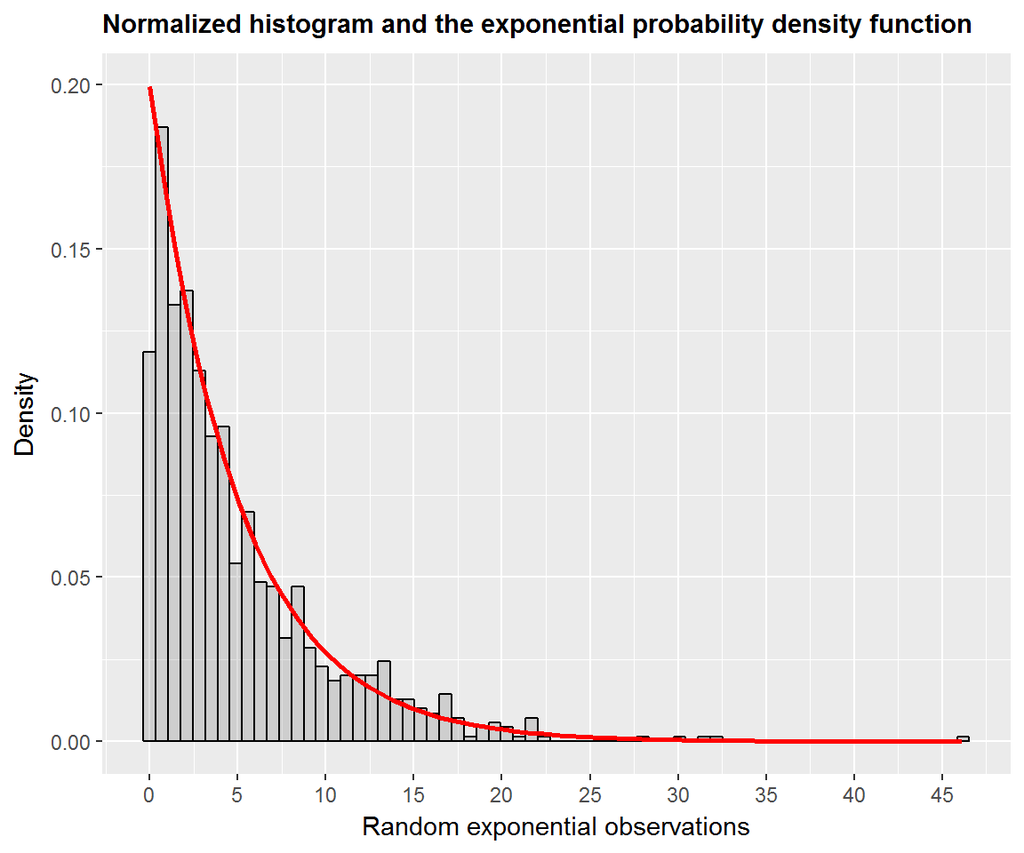

```r
g1 <- ggplot(data = data.frame(x = exp), aes(x = x)) +
         geom_histogram(aes(y = ..density..),
                        binwidth = 0.7,
                        colour = "black",
                        alpha = 0.2) +
         stat_function(fun = dexp,
                       args = list(rate = lambda),
                       lwd = 1,
                       col = "red") +
         scale_x_continuous(breaks = seq(0, 50, 5)) +
         labs(x = "Random exponential observations",
              y = "Density") +
         ggtitle("Normalized histogram and the exponential probability density function") +
         theme(plot.title = element_text(size = 11, face = "bold"))

g1
```

As we can see from the figure above, the empirical distribution of a thousand simulated exponential random variables approximately coincides with the theoretical one, which is represented by the red line.

# 3 Distribution of the exponential sample means

According to the CLT, for sufficiently large $n$ (in our case $n=40$), the exponential sample mean follows a normal distribution with mean equal to the exponential population mean and variance equal to the population variance divided by $n$, i.e. $\bar{X}_n\sim N\left( \dfrac{1}{\lambda}, \dfrac{1}{n\lambda^2} \right)$, where $\bar{X}_n=\dfrac{1}{n}\sum\limits_{i=1}^{n} X_i$. Below we simulate 1000 exponential sample means and we store the result in the numerical vector “exp.means”:

```r
simulations <- 1000

set.seed(123)
exp.means <- sapply(1:simulations, function(i, n, lambda){

   mean(rexp(n, lambda))

}, n = 40, lambda = 0.2)
```

## 3.1 Sample mean versus theoretical mean

As we can see from the code below, the sample mean of the empirical distribution of exponential means is 5.012 and it is approximately equal to the theoretical one, which is $\dfrac{1}{\lambda} = \dfrac{1}{0.2} = 5$:

```r
mean(exp.means)
```

```
## [1] 5.011911
```

Next we show the density plot of the theoretical distribution of the sample means overlaid over the respective histogram, where the probability density function is calculated with mean equal to the theoretical mean - $\dfrac{1}{\lambda}$ and standard deviation equal to $\dfrac{1}{\sqrt{n}\lambda}$. As we can see from the plot below, the large sample distribution of the exponential sample means follows approximately its theoretical distribution, which is the normal distribution with mean equal to $\dfrac{1}{\lambda}=5$ and variance equal to $\dfrac{1}{n\lambda^2}$. It can be seen from the plot that the empirical distribution is symmetric and centered around $\dfrac{1}{\lambda}=5$:

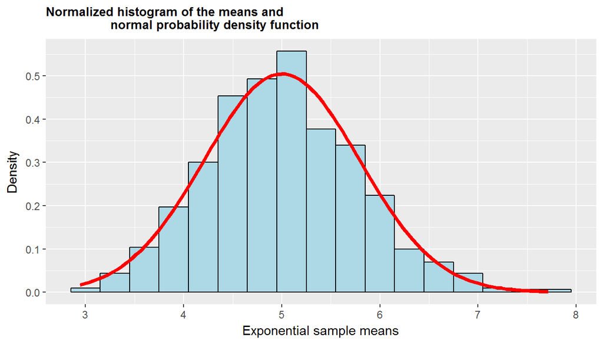

```r
df <- data.frame(means = exp.means)

g2 <- ggplot(data = df, aes(x = df$means)) +
         geom_histogram(aes(y = ..density..),
                        binwidth = 0.3,
                        colour = "black",
                        fill = "lightblue") +
         stat_function(fun = dnorm,
                       args = list(mean = 1/lambda, sd = 1/(lambda*sqrt(n))),
                       lwd = 1.5,
                       col = "red") +
         scale_x_continuous(breaks = seq(0, 8, 1)) +
         scale_y_continuous(breaks = seq(0, 0.6, 0.1)) +
         labs(x = "Exponential sample means",
              y = "Density") +
         ggtitle("Normalized histogram of the means and
                  normal probability density function") +
         theme(plot.title = element_text(size = 10, face = "bold"))

g2
```

## 3.2 Sample variance versus theoretical variance

The sample variance of the empirical distribution of the exponential means is

```r
var.means <- sd(exp.means)^2
var.means
```

```
## [1] 0.6004928
```

and the theoretical variance of the distribution of the exponential means is $\dfrac{1}{n\lambda^2}$:

```r
theory.var <- 1/(n*lambda^2)
theory.var
```

```
## [1] 0.625
```

As the theory suggests, the empirical variance converges to the theoretical one.

# 4 Comparison between the exponential distribution and the distribution of exponential means

Finally we compare the exponential distribution and the distribution of exponential means:

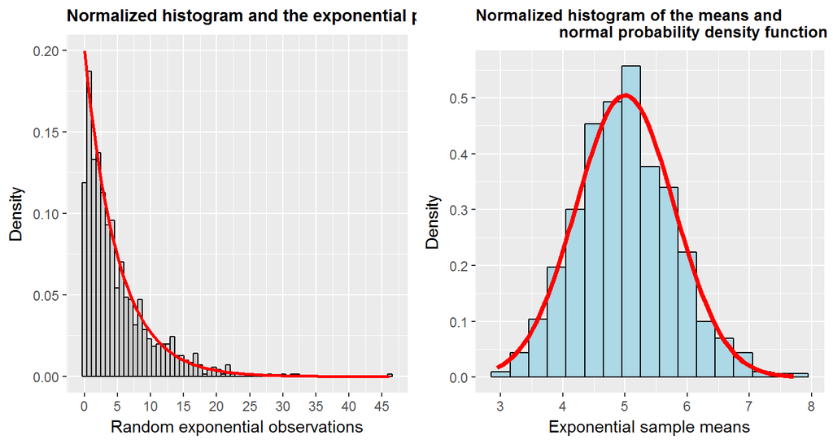

```r
grid.arrange(grobs = list(g1, g2), ncol = 2)
```

On the left figure is shown the distribution of 1000 random exponentials together with the respective theoretical density function (red line). On the right figure we see that the empirical distribution of the sample means resembles the respective theoretical normal distribution (red line) and is centered around 5.

# 5 Summary

We demonstrated numerically that the CLT holds, i.e. we showed that for sufficiently large $n$ (where $n$ is the number of independent and identically distributed exponential observations), the exponential sample mean follows a normal distribution with mean equal to the exponential population mean and variance equal to the population variance divided by $n$.